# 骨髄バンクにおけるナッジ・メッセージの効果検証

Hiroki Kato

Fumio Ohtake

2022/06/20

# Field Experiment

フィールド実験の対象者は骨髄バンクドナー確定後に「適合通知」を受け取るドナー候補者である。 ドナー候補者確定後、骨髄バンクは対象者に幹細胞提供を依頼する「適合通知」および それを郵送した旨を伝えるSNSメーセージを送付する。 我々は行動科学の知見に基づいたメッセージを適合通知に加える介入を実施する。 現行の適合通知（*Basic notification*）は以下の通りである。

> この度、あなたと骨髄バンクの登録患者さんのHLA型（白血球の型）が一致し、 ドナー候補者のおひとりに選ばれました。 今後、ご提供に向け詳しい検査や面談を希望されるかをお伺いしたく連絡させていただきました。 同封の資料をよくお読みいただき、コーディネートが可能かどうか検討の上、 この案内が届いてから７日以内に返信用紙ほかをご返送ください。 返送後、コーディネートを進めさせていただく場合は、 担当者よりご相談のお電話を差し上げますのでよろしくお願い申し上げます。

介入は以上の文章に以下の2種類のメッセージを加える。

- *One chance in million*: １人の登録患者さんとHLA型が一致するドナー登録者は数百〜数万人に1人です。 ドナー候補者が複数みつかる場合もありますが、多くはないこともご理解頂ければ幸いです。
- *Transplant recipient*: 骨髄バンクを介して移植ができる患者さんは現在約6割にとどまっています。 骨髄等を提供するドナーが早く見つかれば、その比率を高めることができます。

現行の適合通知にメッセージを加えないコントロール群（A）に加えて、 我々は2つの介入を用いて3つの実験群を作成した。

1. B: One chance in million
2. C: Transplant recipient
3. D: One chance in million + Transplant recipient

我々はフィールド実験を2021年9月～2022年2月で実施した。 表1に示されているように、我々は週単位で実験群を割り当てる。 このとき、月の固定効果と週の固定効果を取り除くために、 実験群が月単位・各月の週単位でバランスされるように設計した。

Table 1: Assignment Schedule

| week | Month/Year 9/21 | Month/Year 10/21 | Month/Year 11/21 | Month/Year 12/21 | Month/Year 1/22 | Month/Year 2/22 |
| --- | --- | --- | --- | --- | --- | --- |
| 1 | B | C | C | D | B | A |
| 2 | D | B | A | A | C | B |
| 3 | A | D | B | C | D | C |
| 4 | C | A | D | B | A | D |

表2にフィールド実験の概要を示した。

- 実験期間中に合計11,154件の適合通知を送付し、 実験群A・B・C・Dのサンプルサイズは それぞれ2,559件、3,075件、2,754件、2,766件である
- 性別の比率・年齢は実験群間でバランスされているが、 コーディネーション回数はバランスされていない

Table 2: Overview of Field Experiment

|  | Experimental Arms A | Experimental Arms B | Experimental Arms C | Experimental Arms D | p-value |
| --- | --- | --- | --- | --- | --- |
| **A. Intervention** |  |  |  |  |  |
| Basic notification | X | X | X | X |  |
| One chance in million |  | X |  | X |  |
| Transplant recipient |  |  | X | X |  |
| **B. Sample Size** |  |  |  |  |  |
| Number of observations | 2559 | 3075 | 2754 | 2766 |  |
| **C. Covariate** |  |  |  |  |  |
| Age | 38.38 | 38.13 | 37.43 | 37.99 | 0.11 |
| Number of coordinations | 1.61 | 1.59 | 1.63 | 1.56 | 0.01 |
| 1 = Male | 0.62 | 0.63 | 0.63 | 0.61 | 0.33 |

# Results

## Difference-in-mean Test

アウトカム変数は提供に至るまでのプロセスであり、具体的に以下の6つの工程がある。

- Reply to notification: 適合通知に返信したならば1を取る二値変数
- Intention: 提供を希望するという意向を示して返信したならば1を取る二値変数
- Confirmatory typing: 確認検査を実施したならば1を取る二値変数
- Candidate: 第一候補者に選定されたならば1を取る二値変数
- Final consent: 最終同意をしたならば1を取る二値変数
- Donation: 採取をしたならば1を取る二値変数

図1に第一候補者に選定される前のプロセスについての記述統計とt検定の結果を示した。

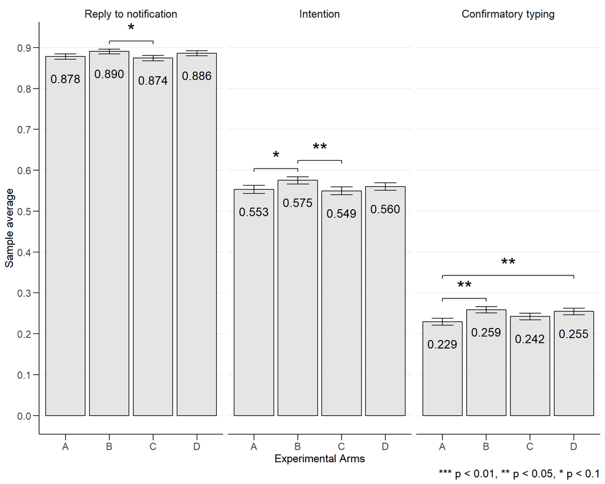

Figure 1: Sample Average of Outcomes before Donor Candidate Selection

図2は第一候補者選定後のプロセスについての記述統計とt検定の結果である。

- いずれの介入も候補者選定・最終同意・提供に影響を与えていない

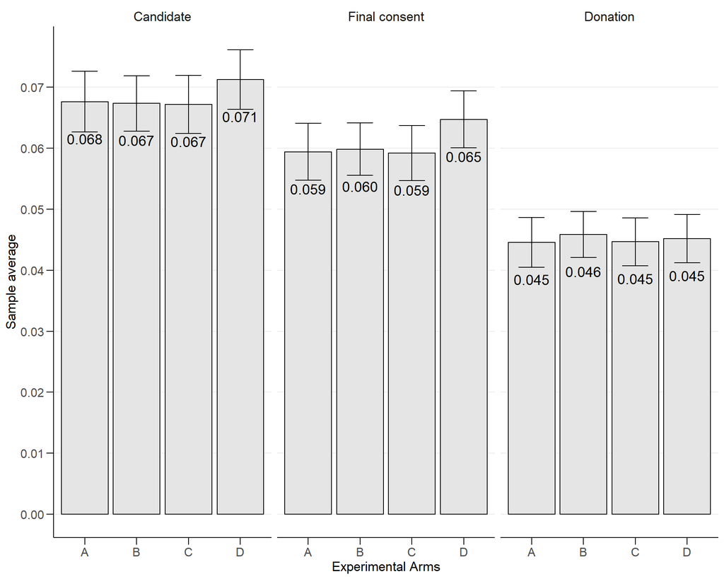

Figure 2: Sample Average of Outcomes after Donor Candidate Selection

## Regression Analysis

$m$月の第$w$週に適合通知を受け取った個人$i$について、 以下の固定効果モデルを考える。
$$Y_{imw} =
\beta_1 \cdot \text{B}_{mw} + \beta_2 \cdot \text{C}_{mw}
+ \beta_3 \cdot \text{D}_{mw}
+ X'_i \gamma + \lambda_m + \theta_w + u_{imw},$$
ここで$X_i$は個人$i$の属性に関する共変量で、 性別・年齢・居住する都道府県・コーディネーション回数であり、 $\lambda_m$と$\theta_w$は週・月の固定効果である。

表3は固定効果モデルの推定結果である。

Table 3: Estimation of Fixed-Effect Models

|  | Reply to notification | Intention | Confirmatory typing | Candidate | Final consent | Donation |
| --- | --- | --- | --- | --- | --- | --- |
| Treatment B | 0.015 | 0.021 | 0.032* | －0.001 | －0.001 | －0.001 |
|  | (0.007) | (0.011) | (0.012) | (0.006) | (0.003) | (0.005) |
| Treatment C | 0.003 | －0.003 | 0.013* | －0.003 | －0.003* | －0.003 |
|  | (0.006) | (0.002) | (0.004) | (0.004) | (0.001) | (0.003) |
| Treatment D | 0.008** | 0.008 | 0.029 | 0.004 | 0.005 | 0.000 |
|  | (0.002) | (0.006) | (0.015) | (0.006) | (0.006) | (0.005) |
| Male | －0.059*** | －0.020** | 0.026 | 0.034** | 0.033*** | 0.025*** |
|  | (0.002) | (0.006) | (0.013) | (0.006) | (0.003) | (0.003) |
| Age | 0.005*** | 0.007*** | －0.002* | －0.001*** | －0.001*** | －0.001*** |
|  | (0.000) | (0.001) | (0.001) | (0.000) | (0.000) | (0.000) |
| Num.Obs. | 11154 | 11154 | 11154 | 11154 | 11154 | 11154 |
| R2 | 0.049 | 0.050 | 0.039 | 0.016 | 0.015 | 0.013 |
| Number of coordinations, prefecture dummies | X | X | X | X | X | X |
| Week and month fixed effect | X | X | X | X | X | X |
| *F-tests, p-value* |  |  |  |  |  |  |
| B = C | 0.176 | 0.065 | 0.108 | 0.699 | 0.549 | 0.601 |
| B = D | 0.316 | 0.159 | 0.865 | 0.384 | 0.206 | 0.680 |
| C = D | 0.418 | 0.097 | 0.403 | 0.373 | 0.234 | 0.392 |

回帰分析の結果はt検定で一貫性に欠けるものだが、 全体的に*One chance in million*の介入を施した介入B群とD群が 適合通知の返信・意向・確認検査の実施に正の影響を与えているかもしれないが、 第一候補者に選ばれた後のプロセスに影響を持たない。

## Heterogenous Effect

性別によってサブサンプルを構築して、固定効果モデルを推定した。

図3にドナー候補者選定前のアウトカムに対するトリートメントの効果をプロットした。

- 男性について、介入B群は確認検査の実施に正の効果を持ち、介入D群は返信に正の効果を持っている
- 女性について、介入D群は確認検査の実施に正の効果を持っている

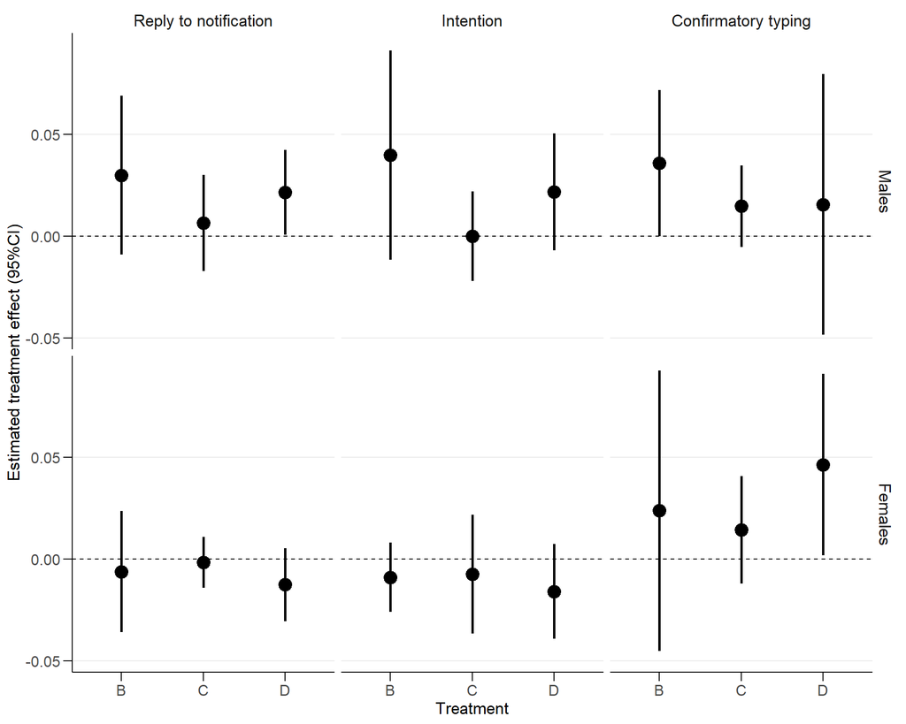

Figure 3: Heterogenous Effect by Gender on Outcomes before Donor Candidate Selection

図4にドナー候補者選定後のアウトカムに対するトリートメントの効果をプロットした。

- 男性について、介入C群は最終同意に負の効果を持っている

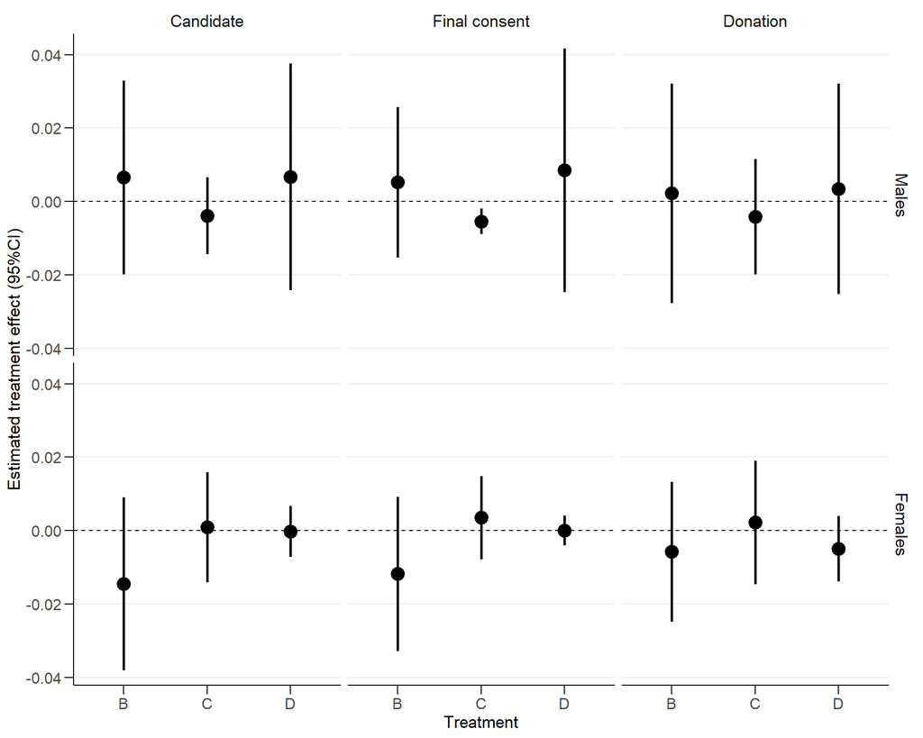

Figure 4: Heterogenous Effect by Gender on Outcomes after Donor Candidate Selection

サンプルを年齢順に4等分して、各サブサンプルで固定効果モデルを推定した。

図5にドナー候補者選定前のアウトカムに対するトリートメントの効果をプロットした。

- 39～46歳のグループについて、介入B群は意向と確認検査の実施に正の効果を持つ

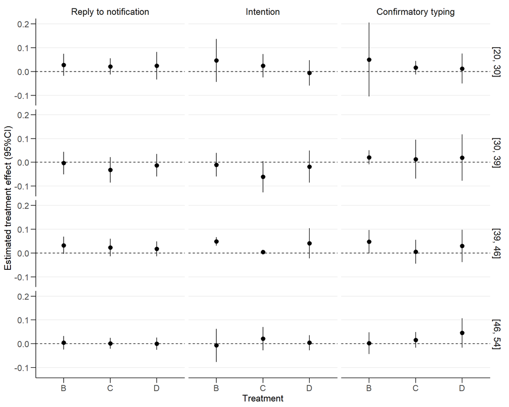

Figure 5: Heterogenous Effect by Age on Outcomes before Donor Candidate Selection

図6にドナー候補者選定後のアウトカムに対するトリートメントの効果をプロットした。

- どの年齢層でも、介入群はアウトカムに影響を与えない

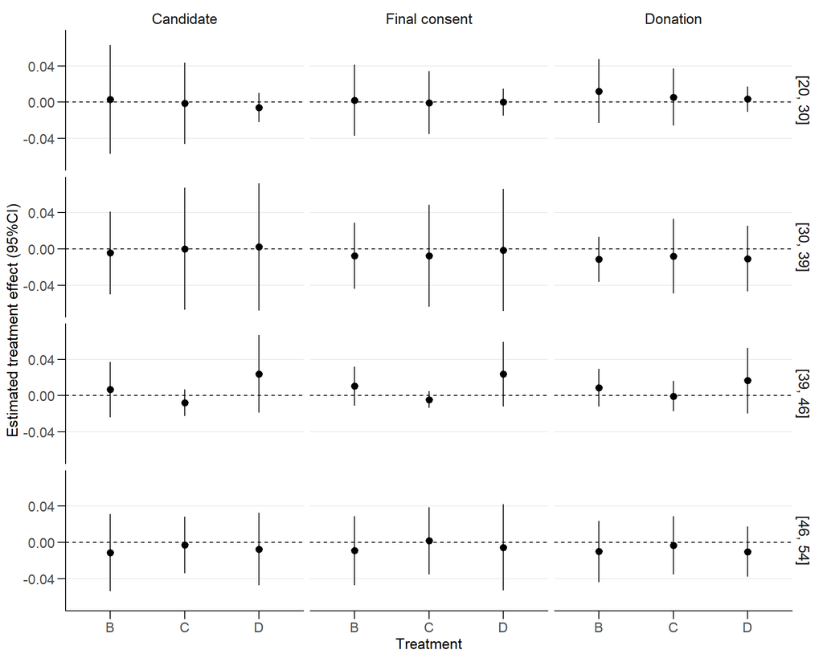

Figure 6: Heterogenous Effect by Age on Outcomes after Donor Candidate Selection